# Fondamenti di scienza dei dati

## Analisi dataset di film

**Studente:** rocco gregori 153316 **Anno Accademico:** 2023-2024

## DESCRIZIONE DEL DATASET

Dataset relativo a **FILM**

Il dataset è preso da KAGGLE

## QUALI DOMANDE MI SONO POSTO?

- Come vengono distribuiti i film per data di uscita?
- Distribuzione dello score
- Score medio?
- Come varia al variare del genere?
- Film che hanno incassato di più
- Generi più popolari
- Generi che guadagnano di più?
- Lingua e Score
- Correlazione tra budget e incassi?

## ANNO DI USCITA

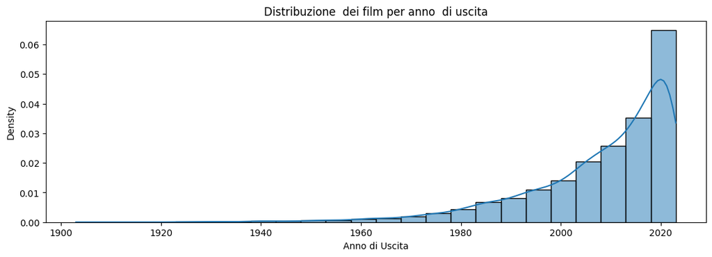

I film vanno dal **15 maggio 1903** al **31 dicembre 2023**  
Distribuzione *assimetrica*!  
I film recenti sono *nettamente* in maggioranza rispetto ai film del 900

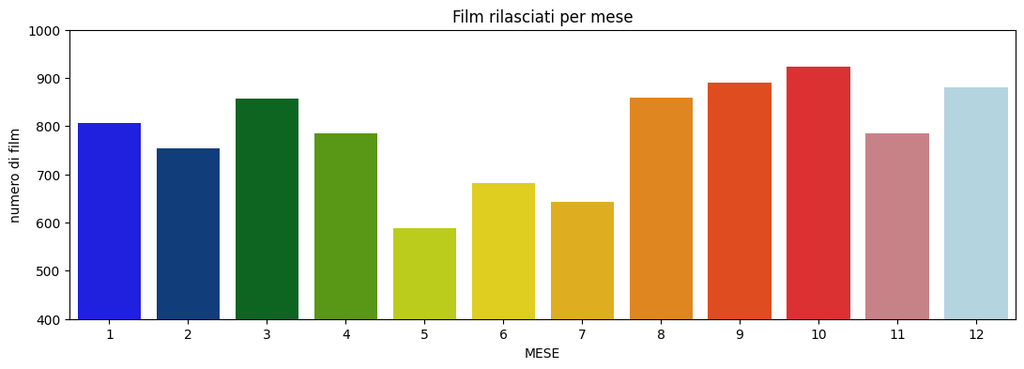

| Mese | N° FIlm |
| --- | --- |
| Ottobre | 923 |
| Settembre | 890 |
| Dicembre | 880 |

## SCORE DEI FILM

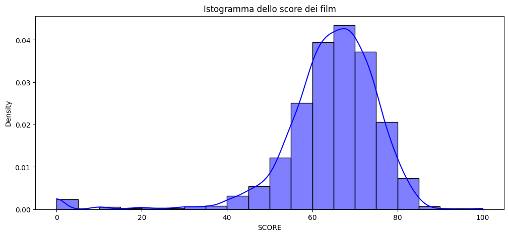

**Score medio** 64  
**Score mediano** 66  
Distribuzione leggermente assimetrica.

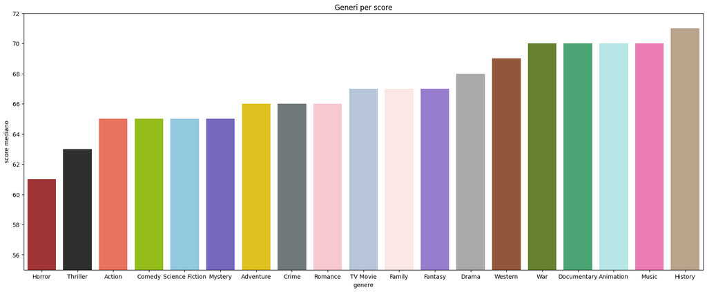

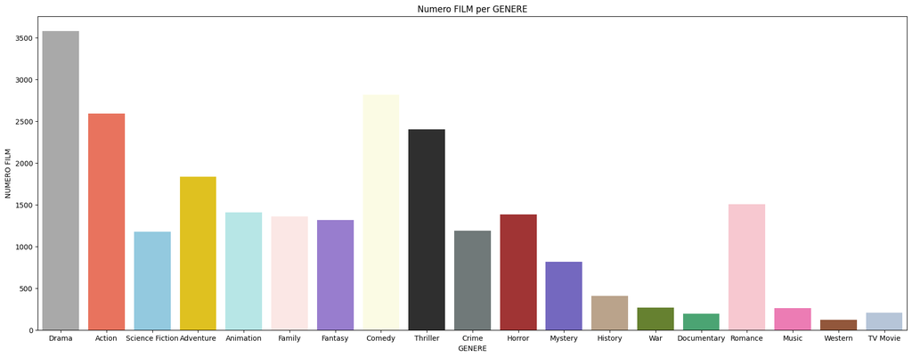

## INCASSI FILM

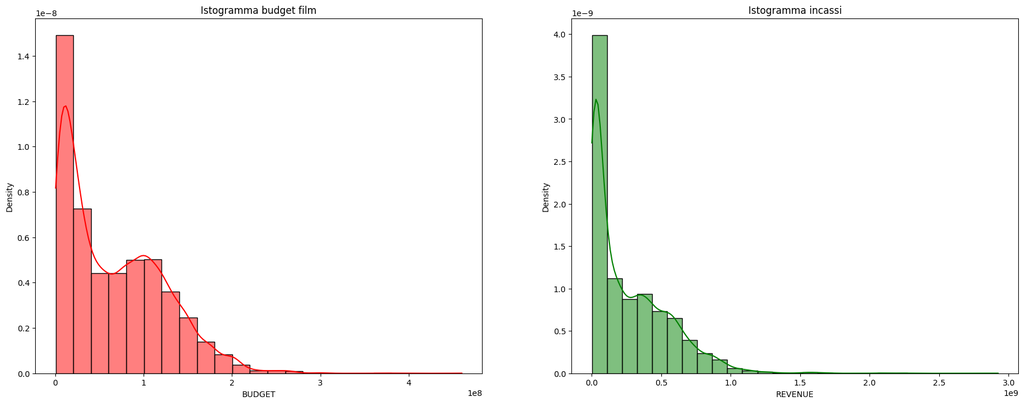

Distribuzione assimetrica per entrambi i grafici.  
Le scale sono diverse

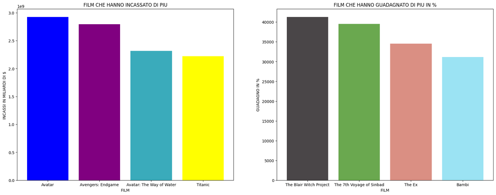

Il grafico di sinistra indica i film con gli incassi totali maggiori  
Il grafico di destra invece mostra i film che hanno guadagnato di più in percentuale al budget per quel film

## GENERE INFLUISCE SUL GUADAGNO ?

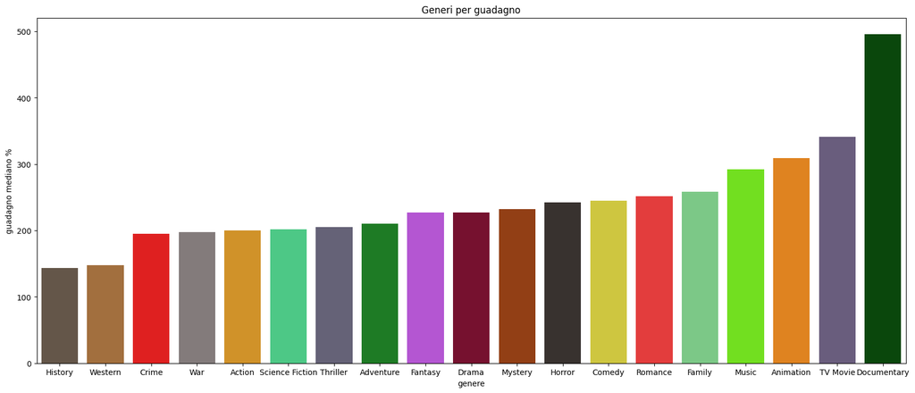

Si può notare una cosa **interessante**.  
I film storici, che sono quelli con lo score medio più elevato, sono i meno 'profittevoli'

## LINGUE DEI FILM

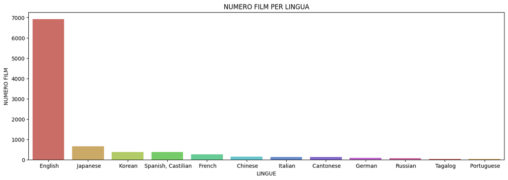

La prevalenza di film in lingua *inglese* è evidente.  
La maggioranza assoluta dei film nel dataset sono in inglese.

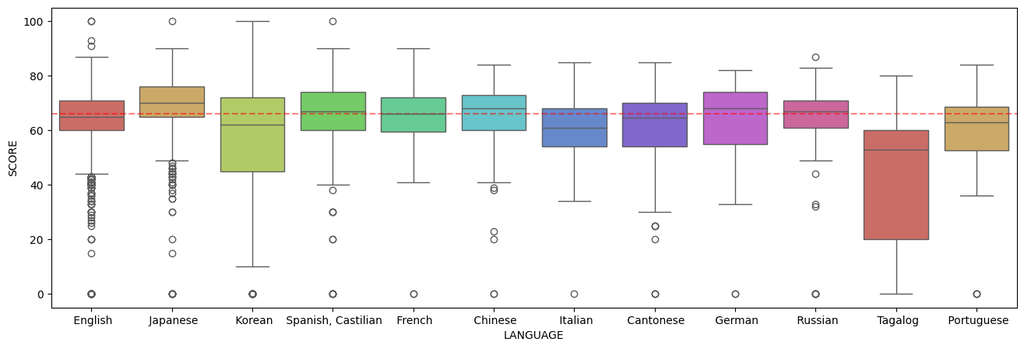

## Correlazione BUDGET E INCASSI

**Coefficiente di Pearson:** 0.691  
**P-Value:**0.00e+00  
*CORRELAZIONE POSITIVA!*

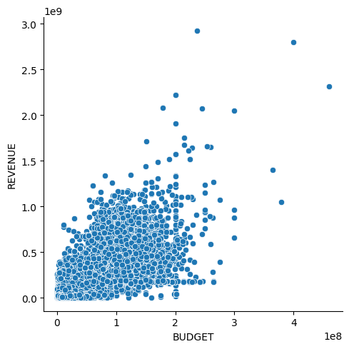

## CONCLUSIONI

Le date di uscita dei film seguono un andamento simil-esponenziale  
Lo score ha una distribuzione a 'campana' ma non è totalmente simmetrica  
Gli Incassi superano Il budget dei film (correlazione positiva)  
La lingua sembra influire, seppure in maniera minimale, allo score del film.